# Fitting Generalized Additive Models

3 June 2026

## Acknowledgments

Gavin Simpson and colleagues have produced a lot of useful teaching material on GAMs that I’ve made use of here. For example:

[Gavin’s blog](https://fromthebottomoftheheap.net)

[Webinar 1](https://www.youtube.com/live/sgw4cu8hrZM?si=pDEYp2OdKB7guJ8T&t=285)

[Webinar 2](https://youtu.be/Ukfvd8akfco?si=g17GQv2ExA1KA0oO&t=8)

## Goals for today

- Understand some diagnostics
- Understand more about model selection techniques with GAMs
- Become familiar with some of the flexibility of GAMs

## Last time

A generalized additive model is an extension of the GLM with a predictor that is a sum of smoothed (and possibly unsmoothed) terms:

\[ y_i = \beta_0 + \sum_j s_j(x_{j,i}) + \sum_k \beta_k x_{k,i} + \epsilon_i \]

And with splines, our smoothed terms are a sum of weighted basis functions:

\[ s(x)=\sum_k \beta_k b_k(x) \]

## Choosing a model

Ask yourself:

- data/error distribution?
- predictors?
- type of smoother(s)?

Check candidate models via diagnostics

- Effect of choice of \(k\) (number of knots)?

## An example

Chicago air quality and death rate ([Peng and Welty (2004)](https://journal.r-project.org/articles/RN-2004-011/RN-2004-011.pdf); `{NMMAPSdata}`)

`death`: total deaths per day

`pm25median`: median particles < 2.5 mg per cubic m

`o3median`: ozone in parts per billion

`tmpd`: temperature in Fahrenheit

```r
## get data
data(chicago, package = "gamair")

## fit gam
fit_gam_air <- mgcv::gam(death ~ s(pm25median) +
                           s(o3median) +
                           s(tmpd),
                         family = "poisson",
                         data = chicago, method = "REML")
```

## An example

Smoothed Terms

```
##                    edf   Ref.df     Chi.sq      p-value
## s(pm25median) 3.518573 4.440907  20.860574 0.0006254809
## s(o3median)   3.430259 4.305665   6.373377 0.2230510318
## s(tmpd)       4.801666 5.878771 244.698414 0.0000000000
```

## GAM interpretation

- Effective degrees of freedom (`edf`) - degree of non-linearity, but with upper bound set by \(k\)
- Reference degrees of freedom (`Ref.df`) - used for calculating test statistic
- `p-value` - null hypothesis is a linear effect (this can include a flat linear effect, i.e., no effect)
  - Biased low because they don’t account for need to estimate \(\lambda\)
  - Works well asymptotically
  - Doesn’t work for unpenalized smooths (random effects)

## Model checking

### Effect of \(k\) on edf (for median particles <2.5 mg per \(m^3\))

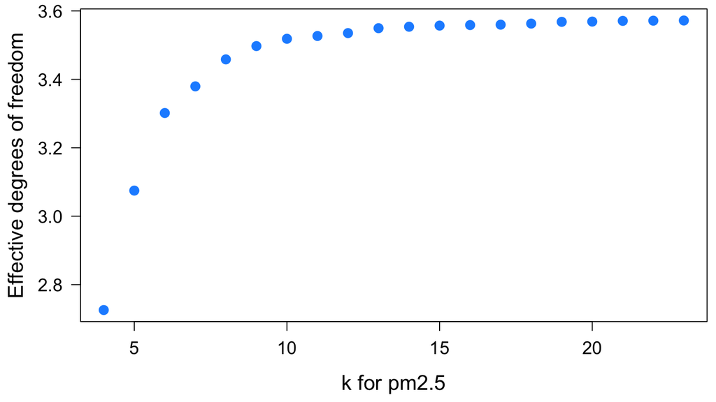

## Model checking

- Check whether \(k\) is adequate - can set it very large to start, but this increases computation time
- Do some iterative checking with larger values of \(k\) for multiple parameters, effective degrees of freedom should stabilize

```r
## check model fit
gam.check(fit_gam_air)
```

## Model checking

### \(k\) set to default for each variable

```
##
## Method: REML   Optimizer: outer newton
## full convergence after 4 iterations.
## Gradient range [-7.763319e-07,1.839545e-08]
## (score 2867.802 & scale 1).
## Hessian positive definite, eigenvalue range [0.2056908,1.115369].
## Model rank =  28 / 28
##
## Basis dimension (k) checking results. Low p-value (k-index<1) may
## indicate that k is too low, especially if edf is close to k'.
##
##                 k'  edf k-index p-value
## s(pm25median) 9.00 3.52    0.99    0.38
## s(o3median)   9.00 3.43    0.97    0.19
## s(tmpd)       9.00 4.80    0.94    0.06 .
## ---
## Signif. codes:  0 '***' 0.001 '**' 0.01 '*' 0.05 '.' 0.1 ' ' 1
```

## Model checking

### Again but with \(k = 20\) for all \(x\)

```r
## fit with k = 20 for all
fit_gam_air <- mgcv::gam(death ~ s(pm25median, k = 20) +
                           s(o3median, k = 20) +
                           s(tmpd, k = 20),
                         family = "poisson",
                         data = chicago, method = "REML")

## check p-values
gam.check(fit_gam_air)
```

## Model checking

### \(p\)-value above \(\alpha\) and edf is not close to \(k\)

```
##
## Method: REML   Optimizer: outer newton
## full convergence after 3 iterations.
## Gradient range [-1.827205e-06,5.041726e-07]
## (score 2867.819 & scale 1).
## Hessian positive definite, eigenvalue range [0.1852984,1.155305].
## Model rank =  58 / 58
##
## Basis dimension (k) checking results. Low p-value (k-index<1) may
## indicate that k is too low, especially if edf is close to k'.
##
##                  k'   edf k-index p-value
## s(pm25median) 19.00  3.57    0.99   0.350
## s(o3median)   19.00  3.59    0.97   0.215
## s(tmpd)       19.00  5.01    0.94   0.075 .
## ---
## Signif. codes:  0 '***' 0.001 '**' 0.01 '*' 0.05 '.' 0.1 ' ' 1
```

## Other model diagnostics

### `gam.check()` provides some basic diagnostic plots

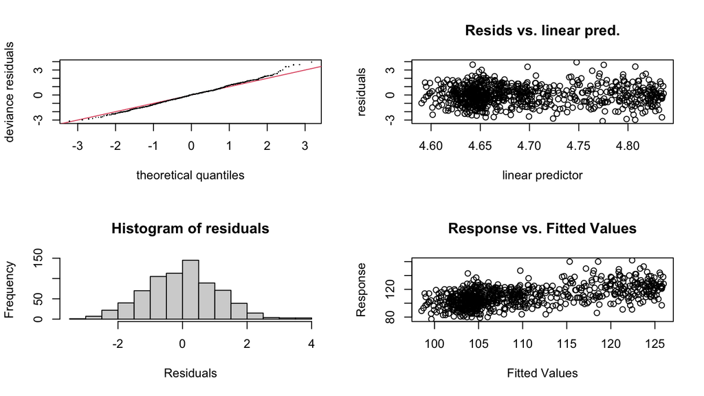

```
##
## Method: REML   Optimizer: outer newton
## full convergence after 3 iterations.
## Gradient range [-1.827205e-06,5.041726e-07]
## (score 2867.819 & scale 1).
## Hessian positive definite, eigenvalue range [0.1852984,1.155305].
## Model rank =  58 / 58
##
## Basis dimension (k) checking results. Low p-value (k-index<1) may
## indicate that k is too low, especially if edf is close to k'.
##
##                  k'   edf k-index p-value
## s(pm25median) 19.00  3.57    0.99    0.32
## s(o3median)   19.00  3.59    0.97    0.24
## s(tmpd)       19.00  5.01    0.94    0.06 .
## ---
## Signif. codes:  0 '***' 0.001 '**' 0.01 '*' 0.05 '.' 0.1 ' ' 1
```

## Model selection

- When we select \(\lambda\) we are only penalizing wiggliness
- However, this only penalizes functions of \(X\) with a second derivative > 0
- Thus, linear relationships can’t be removed from the model this way

## Model selection

Use `select = TRUE` to apply penalties to the linear terms as well

```r
## apply penalties to linear terms
fit_gam_air <- mgcv::gam(death ~ s(pm25median, k = 20) +
                           s(o3median, k = 20) +
                           s(tmpd, k = 20),
                         select = TRUE,
                         family = "poisson",
                         data = chicago, method = "REML")
```

## Model selection

Check to see if edf < 1

```r
## check edf values
summary(fit_gam_air)$s.table
```

```
##                    edf   Ref.df     Chi.sq     p-value
## s(pm25median) 3.567278 4.543784  20.830454 0.000704636
## s(o3median)   3.591463 4.540236   7.006517 0.201616686
## s(tmpd)       5.006420 6.297518 243.866273 0.000000000
```

## Model selection

### Use `gratia::draw()` to create partial effect plots for the smooths

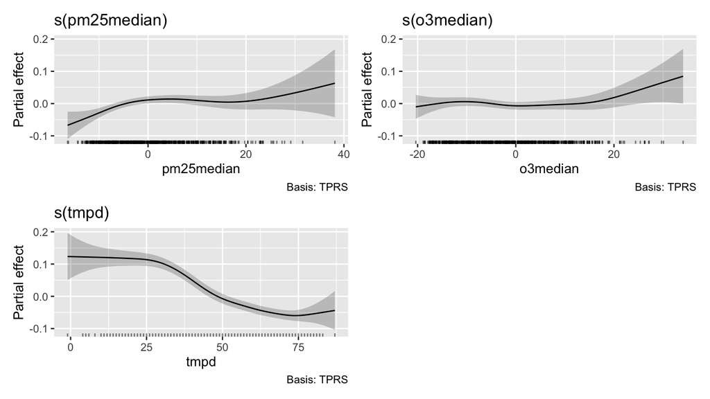

## Flexibility of GAMs

We have *lots* of options when fitting GAMs

so we have to give very careful thought to our goal(s)

## Flexibility of GAMs

We have *lots* of options when fitting GAMs

so we have to give very careful thought to our goal(s)

Just because we *can* fit a GAM doesn’t mean it will be interpretable or useful!

## Another example

### Atmospheric CO<sub>2</sub> concentrations at the South Pole (1957 to 1999)

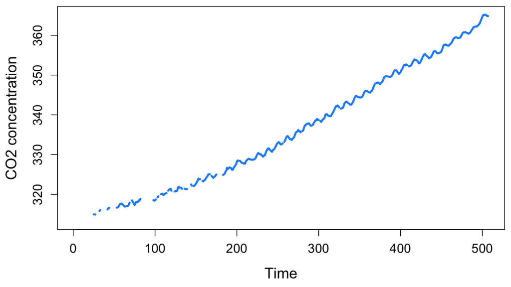

## Candidate model

Cubic regression basis because have a lot of wiggliness in the data

Let’s make \(k\) *really* large then

```r
## fit GAM with cubic regression basis
fit_co2_cubic <- gam(co2 ~ s(c.month, k = 300, bs = "cr"),
                     method = 'REML',
                     data = co2s)
```

## Model summary

```
##
## Family: gaussian
## Link function: identity
##
## Formula:
## co2 ~ s(c.month, k = 300, bs = "cr")
##
## Parametric coefficients:
##              Estimate Std. Error t value Pr(>|t|)
## (Intercept) 3.382e+02  4.444e-03   76111   <2e-16 ***
## ---
## Signif. codes:  0 '***' 0.001 '**' 0.01 '*' 0.05 '.' 0.1 ' ' 1
##
## Approximate significance of smooth terms:
##              edf Ref.df     F p-value
## s(c.month) 205.3  241.4 44646  <2e-16 ***
## ---
## Signif. codes:  0 '***' 0.001 '**' 0.01 '*' 0.05 '.' 0.1 ' ' 1
##
## R-sq.(adj) =      1   Deviance explained =  100%
## -REML = 36.492  Scale est. = 0.0084334  n = 427
```

## Predicting the future

### Not a great model

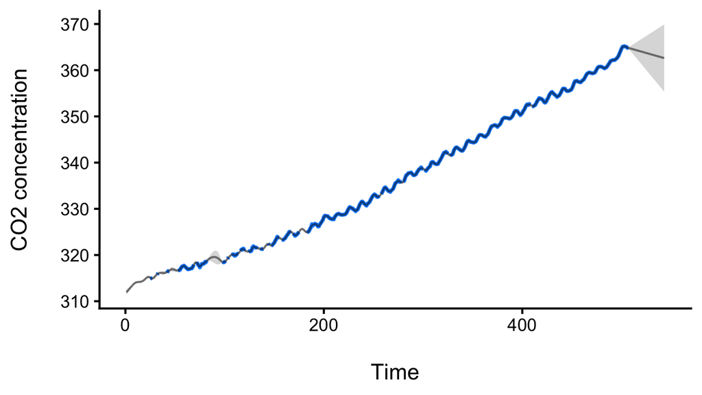

## Another candidate model

Let’s now distinguish within-year variation from the long-term trend

- cyclic spline on `month` (1:12)
- cubic regression spline on `c.month` (1:507)

```r
## fit GAM with
b2 <- gam(co2 ~ s(month, bs = "cc") +
            s(c.month, bs = "cr", k = 300),
          knots = list(month = c(0.5, 12.5)),
          method = 'REML',
          data = co2s)
```

## Cyclic & cubic splines

```
##
## Family: gaussian
## Link function: identity
##
## Formula:
## co2 ~ s(month, bs = "cc") + s(c.month, bs = "cr", k = 300)
##
## Parametric coefficients:
##              Estimate Std. Error t value Pr(>|t|)
## (Intercept) 3.382e+02  5.331e-03   63447   <2e-16 ***
## ---
## Signif. codes:  0 '***' 0.001 '**' 0.01 '*' 0.05 '.' 0.1 ' ' 1
##
## Approximate significance of smooth terms:
##                edf Ref.df       F p-value
## s(month)     7.266    8.0   165.1  <2e-16 ***
## s(c.month) 107.309  131.8 56450.2  <2e-16 ***
## ---
## Signif. codes:  0 '***' 0.001 '**' 0.01 '*' 0.05 '.' 0.1 ' ' 1
##
## R-sq.(adj) =      1   Deviance explained =  100%
## -REML = -103.74  Scale est. = 0.012136  n = 427
```

## Cyclic & cubic splines

### Much more reasonable predictions

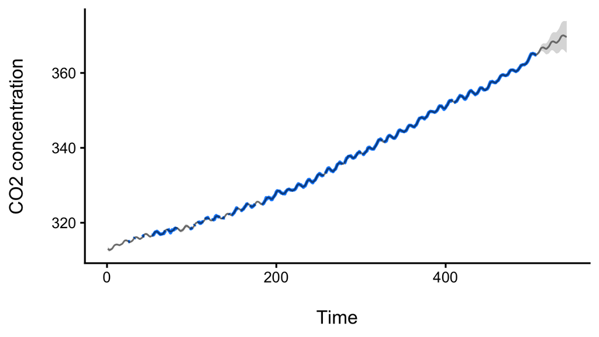

## A cautionary note

Building GAMs requires more choices than building GLMs

It requires thinking hard about the system and the question

## Options for interactions

**main effects & interactions** `te(x1, x2)`

- separate smoothness parameter and separate marginal basis

## Options for interactions

**main effects & interactions** `te(x1, x2)`

- separate smoothness parameter and separate marginal basis

**interactions only** `ti(x1, x2)`

- when the main effect are specified elsewhere

## Options for interactions

**main effects & interactions** `te(x1, x2)`

- separate smoothness parameter and separate marginal basis

**interactions only** `ti(x1, x2)`

- when the main effect are specified elsewhere

**bivariate thin plate splines** `s(x1, x2, bs = 'tp')`

- single smoothness parameter, only use when units are the same (eg, over space)

## Options for interactions

**main effects & interactions** `te(x1, x2)`

- separate smoothness parameter and separate marginal basis

**interactions only** `ti(x1, x2)`

- when the main effect are specified elsewhere

**bivariate thin plate splines** `s(x1, x2, bs = 'tp')`

- single smoothness parameter, only use when units are the same (eg, over space)

**smooth by different levels of a factor** `f + s(x1, by = f)`

- be sure to include the factor as a fixed effect
- akin to random regression slopes

## Mixed models

### GAMMs

We can also fit random effects

- `mgcv::gam(...,`bs = “re”)`
- `mgcv::gamm()`
- `gamm4::gamm4()`

Thus, these models are equivalent:

- `lme(y ~ 1 + (1|f), method = "REML")`
- `gam(y ~ s(f, bs = "re"), method = "REML")`

## Summary

- GAMs using splines offer tremendous flexibility
- There is some tradeoff between flexibility and ease of understanding
- Many of our relationships in ecology aren’t linear
- What are some examples?